# Speech Recognition

This is my first attempt to build a basic speech recognition model using pydub (for pre-processing) and Keras (tensorflow backend). This dataset is a smaller subset of **Tensorflow Speech Recognition** dataset uploaded by **Google Brain** on [**Kaggle**](https://www.kaggle.com/c/tensorflow-speech-recognition-challenge). This kernel is my attempt to get started with smaller dataset and before attempting the bigger problem (Kaggle challenge itself). Hope you find this helpful.

```python
import scandir
import pandas as pd
import numpy as np
from tqdm import tqdm
import matplotlib.pyplot as plt

from scipy.io import wavfile
import IPython
import random
import os
from pydub import AudioSegment, effects

from scipy.signal import spectrogram

from keras.callbacks import ModelCheckpoint
from keras.models import Model, load_model, Sequential
from keras.layers import Dense, Activation, Dropout, Input, Masking, TimeDistributed, LSTM, Conv1D
from keras.layers import GRU, Bidirectional, BatchNormalization, Reshape, Flatten
from keras.optimizers import Adam

from keras.utils import to_categorical
from keras import metrics

from sklearn.utils.class_weight import compute_class_weight
from sklearn.metrics import accuracy_score
from sklearn.utils import shuffle
from sklearn.preprocessing import LabelEncoder

import tensorflow as tf

import pickle
```

Calculate and plot spectrogram for a wav audio file

```python
def graph_spectrogram(wav_file):
    rate, data = wavfile.read(wav_file)
    nfft = 256 # Length of each window segment
    fs = 8000 # Sampling frequencies
    noverlap = 120 # Overlap between windows
    nchannels = data.ndim
    if nchannels == 1:
        pxx, freqs, bins, im = plt.specgram(data, nfft, fs, noverlap = noverlap)
    elif nchannels == 2:
        pxx, freqs, bins, im = plt.specgram(data[:,0], nfft, fs, noverlap = noverlap)
    return pxx
```

Get spectogram (as array of number) for data prerocessinng and modeling step

```python
def get_spectrogram(wav_file):
    rate, data = wavfile.read(wav_file)
    nfft = 256 # Length of each window segment
    fs = 8000 # Sampling frequencies
    noverlap = 120 # Overlap between windows
    nchannels = data.ndim
    if nchannels == 1:
        freqs, bins, Sxx = spectrogram(data, fs=fs, nfft=nfft, noverlap = noverlap)
    elif nchannels == 2:
        freqs, bins, Sxx = spectrogram(data[:,0], fs=fs, nfft=nfft, noverlap = noverlap)
    return Sxx
```

Below is a fucntion for adding `background_noise` to the audio data. It is done for getting more accurate predictions on real world data as we rarely talk or record in completely silent environment. It helps model learn important features (related to words) better.

```python
# function to get 1 sec of random backgroud noise
# may need to add a silent segment to some to keep dimensions same -- AudioSegment.silent(duration=1000 or len(wav_file))
random.seed(42)

def add_noise(audio_file):
    orig_audio = AudioSegment.from_file(audio_file)
    noise_type = random.randint(0,background_noise.shape[1]-1)
    back_noise = AudioSegment.from_file(background_noise['path'].iloc[noise_type])
    if len(back_noise) > len(orig_audio):
        start_of_noise = random.randrange(len(back_noise)-len(orig_audio))
        audio = orig_audio.overlay(back_noise[start_of_noise:start_of_noise+len(orig_audio)])
        return audio
    else:
        audio = orig_audio.overlay(back_noise, loop=true)
        return audio
```

We can also **augment our data** in a similar fashion. It can be done increase training sample size (in turn giving more data to our model for training so it predicts well on testing).  
Below are some of the techniques we can use for Audio data -

1. Time shift
2. Speed Shift
3. Mix background
4. Volumne Tune

For now, let's just get started with reading our data

```python
folder = 'C:/Personal/Speech/speech_sample/' #here your dir path

fname = []
label = []
path = []
uniq_name = []

for paths, dirs, files in scandir.walk(folder):
    for file in files:
        fname.append(file)
        label.append(paths.split('/')[-1])
        path.append(os.path.join(paths, file))
        uniq_name.append(paths.split('/')[-1] + '_' + file)

dic = {'fname':fname, 'labels':label, 'path':path, 'uniq_name': uniq_name}
train = pd.DataFrame.from_dict(dic)

print(train.shape)
train.head()
```

```
(1378, 4)
```

|  | fname | labels | path | uniq_name |
| --- | --- | --- | --- | --- |
| 0 | 00b01445_nohash_0.wav | bird | C:/Personal/Speech/speech_sample/bird\00b01445... | bird_00b01445_nohash_0.wav |
| 1 | 00f0204f_nohash_0.wav | bird | C:/Personal/Speech/speech_sample/bird\00f0204f... | bird_00f0204f_nohash_0.wav |
| 2 | 00f0204f_nohash_1.wav | bird | C:/Personal/Speech/speech_sample/bird\00f0204f... | bird_00f0204f_nohash_1.wav |
| 3 | 00f0204f_nohash_2.wav | bird | C:/Personal/Speech/speech_sample/bird\00f0204f... | bird_00f0204f_nohash_2.wav |
| 4 | 00f0204f_nohash_3.wav | bird | C:/Personal/Speech/speech_sample/bird\00f0204f... | bird_00f0204f_nohash_3.wav |

let's hear one of these

```python
IPython.display.Audio(train['path'].iloc[0])
```

[interactive chart not shown]

```python
IPython.display.Audio(train['path'].iloc[0])
```

[interactive chart not shown]

let's shuffle our training data, and separate background noises from it

```python
train = shuffle(train, random_state=42)
background_noise = train[train['labels'] == '_background_noise_']
train = train[train['labels'] != '_background_noise_']

train.reset_index(drop=True, inplace=True)
background_noise.reset_index(drop=True, inplace=True)

print(train.shape, background_noise.shape)
```

```
(1372, 4) (6, 4)
```

```python
background_noise
```

|  | fname | labels | path | uniq_name |
| --- | --- | --- | --- | --- |
| 0 | white_noise.wav | _background_noise_ | C:/Personal/Speech/speech_sample/_background_n... | _background_noise__white_noise.wav |
| 1 | dude_miaowing.wav | _background_noise_ | C:/Personal/Speech/speech_sample/_background_n... | _background_noise__dude_miaowing.wav |
| 2 | doing_the_dishes.wav | _background_noise_ | C:/Personal/Speech/speech_sample/_background_n... | _background_noise__doing_the_dishes.wav |
| 3 | running_tap.wav | _background_noise_ | C:/Personal/Speech/speech_sample/_background_n... | _background_noise__running_tap.wav |
| 4 | exercise_bike.wav | _background_noise_ | C:/Personal/Speech/speech_sample/_background_n... | _background_noise__exercise_bike.wav |
| 5 | pink_noise.wav | _background_noise_ | C:/Personal/Speech/speech_sample/_background_n... | _background_noise__pink_noise.wav |

Number of classes in our dataset

```python
classes = list(np.unique(train.labels))
classes
```

```
['bird', 'cat', 'dog']
```

**Bird**

let's see how a spectogram for a `'bird'` looks like

```
bird
```

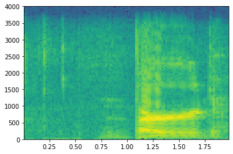

```python
label = train[train['labels']=='bird']['labels'].iloc[0]
path = train[train['labels']=='bird']['path'].iloc[0]
print(label)
x = graph_spectrogram(path)
```

**Cat**

```python
IPython.display.Audio(train[train['labels']=='cat']['path'].iloc[0])
```

[interactive chart not shown]

```
cat
```

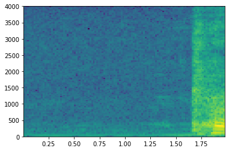

```python
label = train[train['labels']=='cat']['labels'].iloc[0]
path = train[train['labels']=='cat']['path'].iloc[0]
print(label)
x = graph_spectrogram(path)
```

**Dog**

```python
IPython.display.Audio(train[train['labels']=='dog']['path'].iloc[0])
```

[interactive chart not shown]

```
dog
```

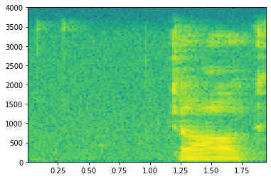

```python
label = train[train['labels']=='dog']['labels'].iloc[0]
path = train[train['labels']=='dog']['path'].iloc[0]
print(label)
x = graph_spectrogram(path)
```

```python
label = train[train['labels']=='dog']['labels'].iloc[0]
path = train[train['labels']=='dog']['path'].iloc[0]
print(label)
x = get_spectrogram(path)
```

```
dog
```

```python
rate, data = wavfile.read(train[train['labels']=='dog']['path'].iloc[0])
print("Time steps in audio recording before spectrogram", data.shape)
print("Time steps in input after spectrogram", x.shape)
print("Rate", rate)
```

```
Time steps in audio recording before spectrogram (15702,)
Time steps in input after spectrogram (129, 114)
Rate 16000
```

**Now, we will create our training data**

We wil randomly select 30% of samples and add noise to them, remaining 70% we will use as it is.

```python
def get_training_data():
    k = int(0.3*train.shape[0])
    indexes_for_adding_noise = random.sample(range(train.shape[0]), k=k)

    for ind in indexes_for_adding_noise:
        audio = add_noise(train['path'].iloc[ind])
        audio.export(train['path'].iloc[ind], format="wav")

    x = []
    for ind in tqdm(train.index):
        one_sec_silence = AudioSegment.silent(duration=1000)
        orig_audio = AudioSegment.from_file(train['path'].iloc[ind])
        if len(orig_audio) == 1000:
            pass
        else:
            audio = orig_audio.overlay(one_sec_silence)
            audio.export(train['path'].iloc[ind], format="wav")

        _x = get_spectrogram(train['path'].iloc[ind])
        x.append(_x)

    le = LabelEncoder()
    _y = le.fit_transform(train['labels'])
    y = to_categorical(_y, num_classes=train['labels'].unique().shape[0])

    with open('C:/Personal/Speech/label_encode.pkl', 'wb') as f:
        pickle.dump(le, f)

    return x, y
```

```python
X, Y = get_training_data()
```

Make sure the dimensions of all arrays in X are same, append with 0's if not

```python
X_final =[]
max_col = np.max(np.unique([x.shape[1] for x in X]))
for i in range(len(X)):
    if X[i].shape[1] < max_col:
        pad_len = max_col - X[i].shape[1]
        x_ = np.pad(X[i], [(0,0),(0,pad_len)], 'constant', constant_values=0)
        X_final.append(x_)
    else:
        X_final.append(X[i])

X = np.asarray(X_final)
```

```python
X.shape, Y.shape
```

```
((1372, 129, 116), (1372, 3))
```

We will save the results to `.npy` file. This is done so that we can use dataset with other models and then compare which model is performing better otherwise we would be comparing models on differnt (bit different) data and then comparision won't be correct

```python
#with open('C:/Personal/Speech/X_Y.npy', 'wb') as f:
#    np.save(f, X)
#    np.save(f, Y)
```

```python
with open('C:/Personal/Speech/X_Y.npy', 'rb') as f:
    Xdash = np.load(f)
    Ydash = np.load(f)
```

```python
Xdash.shape, Ydash.shape
```

```
((1619, 129, 116), (1619, 3))
```

**Now we have the data ready**

We will now define the model function.  
We will use **Conv1D** model for this classification (because our data is 1D)

```python
def get_model(input_shape):

    X_input = Input(shape = input_shape)
    X = Conv1D(filters=64, kernel_size=(5), strides=2)(X_input)
    X = BatchNormalization()(X)
    X = Activation(activation='relu')(X)
    X = Dropout(rate=0.2)(X)

    X = Conv1D(filters=128, kernel_size=(5), strides=2)(X)
    X = BatchNormalization()(X)
    X = Activation(activation='relu')(X)
    X = Dropout(rate=0.5)(X)

    X = Conv1D(filters=256, kernel_size=(5), strides=2)(X)
    X = BatchNormalization()(X)
    X = Activation(activation='relu')(X)
    X = Dropout(rate=0.5)(X)

    X = Flatten()(X)
    X = Dense(256, activation='relu')(X)
    X = Dense(128, activation='relu')(X)
    X = Dense(64, activation='relu')(X)
    X = Dense(32, activation='relu')(X)
    X = Dense(3, activation='softmax')(X)

    model = Model(inputs = X_input, outputs = X)
    return model
```

```python
model = get_model(input_shape = (X.shape[1], X.shape[2]))
```

```python
model.summary()
```

```
Model: "model_1"
_________________________________________________________________
Layer (type)                 Output Shape              Param #
=================================================================
input_1 (InputLayer)         (None, 129, 116)          0
_________________________________________________________________
conv1d_1 (Conv1D)            (None, 63, 64)            37184
_________________________________________________________________
batch_normalization_1 (Batch (None, 63, 64)            256
_________________________________________________________________
activation_1 (Activation)    (None, 63, 64)            0
_________________________________________________________________
dropout_1 (Dropout)          (None, 63, 64)            0
_________________________________________________________________
conv1d_2 (Conv1D)            (None, 30, 128)           41088
_________________________________________________________________
batch_normalization_2 (Batch (None, 30, 128)           512
_________________________________________________________________
activation_2 (Activation)    (None, 30, 128)           0
_________________________________________________________________
dropout_2 (Dropout)          (None, 30, 128)           0
_________________________________________________________________
conv1d_3 (Conv1D)            (None, 13, 256)           164096
_________________________________________________________________
batch_normalization_3 (Batch (None, 13, 256)           1024
_________________________________________________________________
activation_3 (Activation)    (None, 13, 256)           0
_________________________________________________________________
dropout_3 (Dropout)          (None, 13, 256)           0
_________________________________________________________________
flatten_1 (Flatten)          (None, 3328)              0
_________________________________________________________________
dense_1 (Dense)              (None, 256)               852224
_________________________________________________________________
dense_2 (Dense)              (None, 128)               32896
_________________________________________________________________
dense_3 (Dense)              (None, 64)                8256
_________________________________________________________________
dense_4 (Dense)              (None, 32)                2080
_________________________________________________________________
dense_5 (Dense)              (None, 3)                 99
=================================================================
Total params: 1,139,715
Trainable params: 1,138,819
Non-trainable params: 896
_________________________________________________________________
```

```python
model.compile(loss='categorical_crossentropy', optimizer='adam', metrics=["accuracy"])
```

```python
model.fit(X, Y, batch_size = 64, epochs=20, validation_split=0.1, verbose=2)
```

```
Train on 1234 samples, validate on 138 samples
 - 3s - loss: 1.0423 - accuracy: 0.4587 - val_loss: 0.9827 - val_accuracy: 0.6449
 - 2s - loss: 0.9261 - accuracy: 0.5089 - val_loss: 0.9371 - val_accuracy: 0.5797
 - 2s - loss: 0.8646 - accuracy: 0.5689 - val_loss: 0.7911 - val_accuracy: 0.6087
 - 2s - loss: 0.8170 - accuracy: 0.6094 - val_loss: 0.7494 - val_accuracy: 0.6522
 - 2s - loss: 0.7184 - accuracy: 0.6629 - val_loss: 0.7580 - val_accuracy: 0.6522
 - 2s - loss: 0.6261 - accuracy: 0.7147 - val_loss: 0.7218 - val_accuracy: 0.6232
 - 2s - loss: 0.5868 - accuracy: 0.7423 - val_loss: 0.7278 - val_accuracy: 0.6377
 - 2s - loss: 0.5480 - accuracy: 0.7553 - val_loss: 0.6030 - val_accuracy: 0.7174
 - 2s - loss: 0.5299 - accuracy: 0.7536 - val_loss: 0.6178 - val_accuracy: 0.7101
 - 2s - loss: 0.4816 - accuracy: 0.8071 - val_loss: 0.7497 - val_accuracy: 0.6812
 - 2s - loss: 0.4289 - accuracy: 0.8152 - val_loss: 0.5120 - val_accuracy: 0.7391
 - 2s - loss: 0.3994 - accuracy: 0.8233 - val_loss: 0.5206 - val_accuracy: 0.7319
 - 2s - loss: 0.3951 - accuracy: 0.8339 - val_loss: 0.5984 - val_accuracy: 0.7174
 - 2s - loss: 0.4025 - accuracy: 0.8209 - val_loss: 0.5189 - val_accuracy: 0.7609
 - 2s - loss: 0.3630 - accuracy: 0.8347 - val_loss: 0.4475 - val_accuracy: 0.7609
 - 2s - loss: 0.3935 - accuracy: 0.8371 - val_loss: 0.4478 - val_accuracy: 0.7899
 - 2s - loss: 0.3627 - accuracy: 0.8428 - val_loss: 0.5021 - val_accuracy: 0.7464
 - 2s - loss: 0.3483 - accuracy: 0.8493 - val_loss: 0.6813 - val_accuracy: 0.7754
 - 2s - loss: 0.3342 - accuracy: 0.8606 - val_loss: 0.4956 - val_accuracy: 0.7899
 - 2s - loss: 0.3358 - accuracy: 0.8452 - val_loss: 0.4695 - val_accuracy: 0.7826
```

```
<keras.callbacks.callbacks.History at 0x1e6cbe39240>
```

**let's now predict on new test dataset (not seen by model)**

Perform same steps for test data preprocessing

```python
test_folder = 'C:/Personal/Speech/test_set/' #here your dir path

fname = []
label = []
path = []
uniq_name = []

for paths, dirs, files in scandir.walk(test_folder):
    for file in files:
        fname.append(file)
        label.append(paths.split('/')[-1])
        path.append(os.path.join(paths, file))
        uniq_name.append(paths.split('/')[-1] + '_' + file)

dic = {'fname':fname, 'labels':label, 'path':path, 'uniq_name': uniq_name}
test = pd.DataFrame.from_dict(dic)

test = test.iloc[1:]
test.reset_index(drop=True, inplace=True)

print(test.shape)
test.head()
```

```
(90, 4)
```

|  | fname | labels | path | uniq_name |
| --- | --- | --- | --- | --- |
| 0 | c08e5058_nohash_0.wav | bird | C:/Personal/Speech/test_set/bird\c08e5058_noha... | bird_c08e5058_nohash_0.wav |
| 1 | c08e5058_nohash_1.wav | bird | C:/Personal/Speech/test_set/bird\c08e5058_noha... | bird_c08e5058_nohash_1.wav |
| 2 | c08e5058_nohash_2.wav | bird | C:/Personal/Speech/test_set/bird\c08e5058_noha... | bird_c08e5058_nohash_2.wav |
| 3 | c0e8f5a1_nohash_0.wav | bird | C:/Personal/Speech/test_set/bird\c0e8f5a1_noha... | bird_c0e8f5a1_nohash_0.wav |
| 4 | c0f8f4df_nohash_0.wav | bird | C:/Personal/Speech/test_set/bird\c0f8f4df_noha... | bird_c0f8f4df_nohash_0.wav |

```python
audio_dir = 'C:/Personal/Speech/test_set/'

def get_test_data():

    x = []
    for ind in tqdm(test.index):
        one_sec_silence = AudioSegment.silent(duration=1000)
        orig_audio = AudioSegment.from_file(test['path'].iloc[ind])
        if len(orig_audio) == 1000:
            pass
        else:
            audio = orig_audio.overlay(one_sec_silence)
            audio.export(test['path'].iloc[ind], format="wav")

        _x = get_spectrogram(test['path'].iloc[ind])
        x.append(_x)

    with open('C:/Personal/Speech/label_encode.pkl', 'rb') as f:
        le = pickle.load(f)

    _y = le.fit_transform(test['labels'])
    y = to_categorical(_y, num_classes=test['labels'].unique().shape[0])


    return x, y
```

```python
X_test, Y_test = get_test_data()
```

```python
X_final =[]
max_col = np.max(np.unique([x.shape[1] for x in X_test]))
for i in range(len(X_test)):
    if X_test[i].shape[1] < max_col:
        pad_len = max_col - X_test[i].shape[1]
        x_ = np.pad(X_test[i], [(0,0),(0,pad_len)], 'constant', constant_values=0)
        X_final.append(x_)
    else:
        X_final.append(X_test[i])

X_test = np.asarray(X_final)
```

```python
y_pred = model.predict(X_test)
```

```python
#model.compile(loss='categorical_crossentropy', optimizer='adam', metrics=['accuracy'])
score, acc = model.evaluate(X_test, Y_test)
```

```python
print('Test accuracy:', acc)
```

```
Test accuracy: 0.7666666507720947
```

**Wow! test accuracy is also close training - 76%**,  
It means our modeling was fine but there seems to a bias issue, probably more training (epochs) or more training data should solve the issue